# Analisi Data Covid19 di Indonesia dan Jabar

Alfazrin Banapon

August 20, 2020

### Latar Belakang Project

COVID-19 merupakan penyakit yang saat ini telah menjadi pandemi secara global. Kondisi menjadi semakin mengkhawatirkan karena hingga detik ini masih belum ditemukan vaksin yang efektif untuk virus penyebab COVID-19. Pemerintah di berbagai negara umumnya dengan sigap membentuk gugus tugas *(task force unit)* untuk menangani penyebaran COVID-19 di masyarakat, termasuk pemerintah di Indonesia.

Salah satu bentuk aksi yang dilakukan oleh pemerintah adalah dengan mengumpulkan dan menyediakan data pertumbuhan kasus COVID-19 kepada publik. Data pertumbuhan kasus tersebut tidak jarang juga dilengkapi dengan dasbor dan grafik visualisasi pendukung dengan harapan masyarakat dapat memahami informasi dengan lebih mudah. Sebagai contoh adalah portal covid19.go.id besutan Gugus Tugas Penanganan COVID-19 Nasional dan portal [PIKOBAR](https://pikobar.jabarprov.go.id/data) milik pemerintah Provinsi Jawa Barat. Serta banyak portal data COVID-19 lainnya yang disediakan oleh masing-masing pemerintah daerah.

### Warming Up!

Sebagai pemanasan sebelum Anda memulai proyek ini, buatlah sebuah vektor karakter dengan 3 elemen dengan nama **bersatulawancovid** yang merupakan kunci dasar menghindari COVID-19!

Jangan lupa untuk mencetak vektor **bersatulawancovid** tersebut pada layar konsol!

```r
bersatulawancovid <- c("cuci tangan","pakai masker","jaga jarak")
bersatulawancovid
```

```
## [1] "cuci tangan"  "pakai masker" "jaga jarak"
```

### Are You Ready ?

Dalam proyek ini, Anda akan diminta untuk melakukan eksplorasi dan analisis mengenai COVID-19 di Indonesia. Data yang Anda pergunakan diambil langsung dari API *(Application Programming Interface)* yang tersedia di covid19.go.id. Sehingga dalam proyek ini Anda akan mempelajari teknik mengambil data dari API, teknik mempersiapkan data, serta analisis dan visualisasi data.

Apakah Anda siap untuk mengerjakan proyek analisis data ini? Jawablah dengan `TRUE` apabila Anda siap atau `FALSE` jika Anda belum siap karena belum mencuci tangan.

```r
TRUE
```

```
## [1] TRUE
```

### Mengakses API covid.go.id

Rekapitulasi data COVID-19 Indonesia tersedia dalam API publik yang beralamat di [https://data.covid19.go.id/public/api/update.json] (https://data.covid19.go.id/public/api/update.json).

Salah satu cara untuk mengakses API adalah dengan menggunakan fungsi `GET()` dari paket `httr`.

Sekarang aktifkanlah paket `httr` dan jalankan fungsi `GET()` pada alamat API yang telah disebutkan! Simpan hasil fungsi tersebut dalam obyek bernama **resp**.

```r
library(httr)
resp <- GET ("https://data.covid19.go.id/public/api/update.json")
```

### Mengevaluasi Respon

Saat Anda menjalankan fungsi `GET()`, pada dasarnya hal yang terjadi adalah Anda membuat sebuah permintaan kepada server penyedia API. Permintaan Anda tersebut selanjutnya diproses dan dijawab oleh server sebagai sebuah respon. Objek **resp** yang telah Anda buat memiliki informasi respon oleh server.

Ada tiga informasi utama dalam sebuah respon API, yaitu **status, headers, dan body**. Status memiliki informasi apakah permintaan Anda berhasil atau tidak dan dinyatakan dalam **status code, headers** umumnya mengandung informasi metadata, sedangkan **bod** berisikan konten atas permintaan yang telah dibuat.

### Menguji Pemahaman akan Respon

Benar atau salahkah bahwa informasi metadata disimpan di dalam body?

- TRUE
- **FALSE**

### Status Code

Ada beberapa jenis status code yang umumnya dijumpai, antara lain:

- 200, Artinya permintaan sukses dipenuhi.
- 404, Artinya berkas yang diminta tidak dapat ditemukan.
- 403, Artinya akses permintaan ditolak.
- 500, Artinya terjadi kesalahan pada server.

Informasi lengkap mengenai jenis-jenis status code dapat diakses melalui :

https://restfulapi.net/http-status-codes/

Anda dapat menggunakan fungsi `status_code()` untuk mengetahui status atas permintaan Anda melalui API. **Sekarang coba lihatlah status atas permintaan yang telah Anda buat! Apakah permintaan Anda berhasil?**

```r
library(httr)
resp <- GET("https://data.covid19.go.id/public/api/update.json")
status_code(resp)
```

```
## [1] 200
```

### Status Code - 2

Selain menggunakan fungsi `status_code()`, Anda juga dapat mengetahui status permintaan dengan cara mengakses elemen dari **resp**. *Status code* tersebut tersedia dengan nama `status_code` dan dapat diakses dengan menggunakan operator **$** pada obyek **resp**. Cobalah kembali akses status code dengan cara tersebut dan bandingkan hasilnya dengan cara pertama!

```r
library(httr)
resp <- GET("https://data.covid19.go.id/public/api/update.json")

resp$status_code
```

```
## [1] 200
```

```r
identical(resp$status_code, status_code(resp))
```

```
## [1] TRUE
```

### Headers API

Selamat status permintaan Anda melalui API sukses dipenuhi! Sekarang cobalah Anda jalankan fungsi `headers()` pada `resp` untuk mengetahui metadata apa saja yang tersimpan. Apakah isi dari elemen content-type? Kapan terakhir kali informasi diperbaharui?

```r
library(httr)
resp <- GET("https://data.covid19.go.id/public/api/update.json")

headers(resp)
```

```
## $server
## [1] "nginx"
##
## $date
## [1] "Sat, 22 Aug 2020 04:11:00 GMT"
##
## $`content-type`
## [1] "application/json"
##
## $`last-modified`
## [1] "Sat, 22 Aug 2020 04:09:43 GMT"
##
## $`transfer-encoding`
## [1] "chunked"
##
## $connection
## [1] "keep-alive"
##
## $vary
## [1] "Accept-Encoding"
##
## $etag
## [1] "W/\"5f409a87-100ea\""
##
## $`content-encoding`
## [1] "gzip"
##
## attr(,"class")
## [1] "insensitive" "list"
```

### Mengekstrak isi Respon

Respon API dengan status code 200 menyatakan bahwa permintaan Anda berhasil dipenuhi dan konten yang diminta tersedia untuk diekstrak. Selain itu Anda juga telah mengetahui lewat fungsi `headers()` bahwa konten yang diminta tersedia dalam bentuk application/json, yaitu berkas JSON.

Selanjutnya Anda dapat mengekstrak konten tersebut dengan menggunakan fungsi `content()`. Fungsi `content()` tersebut secara cerdas akan menyesuaikan output sesuai dengan jenis berkas yang tersedia, dalam hal ini adalah berkas JSON. Jalankan fungsi tersebut pada obyek **resp** dan tambahkan argumen `as = "parsed"` dan `simplifyVector = TRUE`. Simpanlah hasilnya sebagai cov_id_raw!

```r
library(httr)
resp <- GET("https://data.covid19.go.id/public/api/update.json")
cov_id_raw <- content(resp, as = "parsed", simplifyVector = TRUE)
```

### Mengekstrak isi Respon - Pt 2

Dengan menggunakan fungsi `length()` dan `names()` cobalah amati ada berapa komponen serta apa saja nama komponen dalam obyek **cov_id_raw** tersebut! Kemudian ekstraklah komponen ke-2 dan simpan dengan nama **cov_id_update**.

```r
length(cov_id_raw)
```

```
## [1] 2
```

```r
names(cov_id_raw)
```

```
## [1] "data"   "update"
```

```r
cov_id_update <- cov_id_raw$update
```

### Analisa Data

Sekarang Anda diminta untuk fokus pada obyek cov_id_update untuk menjawab pertanyaan-pertanyaan berikut:

- Kapan tanggal pembaharuan data penambahan kasus?
- Berapa jumlah penambahan kasus sembuh?
- Berapa jumlah penambahan kasus meninggal?
- Berapa jumlah total kasus positif hingga saat ini?
- Berapa jumlah total kasus meninggal hingga saat ini?

```r
lapply(cov_id_update,names)
```

```
## $penambahan
## [1] "jumlah_positif"   "jumlah_meninggal" "jumlah_sembuh"
## [4] "jumlah_dirawat"   "tanggal"          "created"
##
## $harian
##  [1] "key_as_string"        "key"                  "doc_count"
##  [4] "jumlah_meninggal"     "jumlah_sembuh"        "jumlah_positif"
##  [7] "jumlah_dirawat"       "jumlah_positif_kum"   "jumlah_sembuh_kum"
## [10] "jumlah_meninggal_kum" "jumlah_dirawat_kum"
##
## $total
## [1] "jumlah_positif"   "jumlah_dirawat"   "jumlah_sembuh"
## [4] "jumlah_meninggal"
```

```r
cov_id_update$penambahan$tanggal
```

```
## [1] "2020-08-21"
```

```r
cov_id_update$penambahan$jumlah_sembuh
```

```
## [1] 2317
```

```r
cov_id_update$penambahan$jumlah_meninggal
```

```
## [1] 82
```

```r
cov_id_update$total$jumlah_positif
```

```
## [1] 149408
```

```r
cov_id_update$total$jumlah_meninggal
```

```
## [1] 6500
```

### Lawan COVID-19!

Jumlah masyarakat yang terinfeksi dan meninggal akibat COVID-19 sudah sangat banyak! Kita harus waspada namun tetap tenang dalam menghadapi masa pandemi ini. Masih ingatkah Anda apa 3 langkah sederhana melawan COVID-19? **Cuci tangan, pakai masker, dan jaga jarak**_.

### Apa Kabar Jawa Barat?

Anda telah berhasil menjawab pertanyaan mengenai kondisi COVID-19 di Indonesia dengan menggunakan data yang langsung diambil menggunakan API. Namun bagaimana jika Anda ingin berfokus dengan data COVID-19 di provinsi tempat menetap saat ini?

covid19.go.id menyediakan data kasus COVID-19 tingkat provinsi di alamat API yang berbeda. Sebagai contoh data mengenai COVID-19 Jawa Barat, tempat tinggal saya sekarang, tersedia di https://data.covid19.go.id/public/api/prov_detail_JAWA_BARAT.json dan dapat diakses menggunakan baris kode berikut:

```
resp_jabar <- GET("https://data.covid19.go.id/public/api/prov_detail_JAWA_BARAT.json")
cov_jabar_raw <- content(resp_jabar, as = "parsed", simplifyVector = TRUE)
```

Sekarang jalankanlah fungsi `names()` pada **cov_jabar_raw** tersebut untuk mengetahui nama-nama elemen utama yang tersedia dan jawablah pertanyaan berikut:

- Berapa jumlah total kasus COVID-19 di Jawa Barat?
- Berapa persentase kematian akibat COVID-19 di Jawa Barat?
- Berapa persentase tingkat kesembuhan dari COVID-19 di Jawa Barat?

```r
library(httr)
resp_jabar <- GET("https://data.covid19.go.id/public/api/prov_detail_JAWA_BARAT.json")
cov_jabar_raw <- content(resp_jabar, as = "parsed", simplifyVector = TRUE)

names(cov_jabar_raw)
```

```
##  [1] "last_date"            "provinsi"             "kasus_total"
##  [4] "kasus_tanpa_tgl"      "kasus_dengan_tgl"     "meninggal_persen"
##  [7] "meninggal_tanpa_tgl"  "meninggal_dengan_tgl" "sembuh_persen"
## [10] "sembuh_tanpa_tgl"     "sembuh_dengan_tgl"    "list_perkembangan"
## [13] "data"
```

```r
cov_jabar_raw$kasus_total
```

```
## [1] 9081
```

```r
cov_jabar_raw$meninggal_persen
```

```
## [1] 2.775025
```

```r
cov_jabar_raw$sembuh_persen
```

```
## [1] 54.72966
```

### Memperoleh Informasi yang Lebih Lengkap

Informasi umum mengenai COVID-19 di Jawa Barat telah Anda dapatkan. Namun informasi akan lebih lengkap jika Anda memiliki data perkembangan COVID-19 dari waktu ke waktu, apakah Anda setuju?

Kabar baiknya adalah informasi tersebut juga disediakan oleh covid19.go.id melalui permintaan API yang telah Anda buat sebelumnya. Data historis perkembangan COVID-19 tersebut tersimpan dengan nama **list_perkembangan**. Silakan Anda ekstrak data tersebut dari **cov_jabar_raw** dan simpanlah hasilnya sebagai obyek bernama **cov_jabar!** Amati struktur **cov_jabar** menggunakan fungsi `str()` dan `head()`.

```r
cov_jabar <- cov_jabar_raw$list_perkembangan
str(cov_jabar)
```

```
## 'data.frame':    174 obs. of  9 variables:
##  $ tanggal                     : num  1.58e+12 1.58e+12 1.58e+12 1.58e+12 1.58e+12 ...
##  $ KASUS                       : int  3 0 1 1 0 1 0 0 0 0 ...
##  $ MENINGGAL                   : int  0 0 1 0 0 0 0 0 0 0 ...
##  $ SEMBUH                      : int  0 0 0 0 0 0 0 0 0 0 ...
##  $ DIRAWAT_OR_ISOLASI          : int  3 0 0 1 0 1 0 0 0 0 ...
##  $ AKUMULASI_KASUS             : int  3 3 4 5 5 6 6 6 6 6 ...
##  $ AKUMULASI_SEMBUH            : int  0 0 0 0 0 0 0 0 0 0 ...
##  $ AKUMULASI_MENINGGAL         : int  0 0 1 1 1 1 1 1 1 1 ...
##  $ AKUMULASI_DIRAWAT_OR_ISOLASI: int  3 3 3 4 4 5 5 5 5 5 ...
```

```r
head(cov_jabar)
```

```
##        tanggal KASUS MENINGGAL SEMBUH DIRAWAT_OR_ISOLASI AKUMULASI_KASUS
## 1 1.583021e+12     3         0      0                  3               3
## 2 1.583107e+12     0         0      0                  0               3
## 3 1.583194e+12     1         1      0                  0               4
## 4 1.583280e+12     1         0      0                  1               5
## 5 1.583366e+12     0         0      0                  0               5
## 6 1.583453e+12     1         0      0                  1               6
##   AKUMULASI_SEMBUH AKUMULASI_MENINGGAL AKUMULASI_DIRAWAT_OR_ISOLASI
## 1                0                   0                            3
## 2                0                   0                            3
## 3                0                   1                            3
## 4                0                   1                            4
## 5                0                   1                            4
## 6                0                   1                            5
```

### Menjinakkan Data

Setelah mengekstrak dan mengamati **cov_jabar**, Anda menemukan beberapa kejanggalan pada data tersebut. Diantaranya adalah kejanggalan data pada kolom tanggal dan format penulisan kolom yang tidak konsisten. Sekarang Anda akan mencoba melakukan beberapa tahapan untuk menjinakan data tersebut sehingga dapat diolah dan dianalisis dengan lebih mudah.

Sebelum itu, silakan Anda aktifkan paket `dplyr` yang akan dipergunakan untuk melakukan pengolahan data.

Ada beberapa tahapan yang akan Anda lakukan untuk menjinakan data **cov_jabar**, yaitu:

1. Menghapus kolom “DIRAWAT_OR_ISOLASI” dan “AKUMULASI_DIRAWAT_OR_ISOLASI”
2. Menghapus semua kolom yang berisi nilai kumulatif
3. Mengganti nama kolom “KASUS” menjadi “kasus_baru”
4. Merubah format penulisan kolom berikut menjadi huruf kecil
   - kolom MENINGGAL
   - kolom SEMBUH
5. Memperbaiki data pada kolom tanggal

Lengkapilah baris kode berikut untuk melakukan menjinakan data sesuai dengan tahapan yang telah Anda rencanakan! Anda akan menggunakan operator pipe **(%>%)** untuk merangkai fungsi menjadi sebuah pipeline. Simpan hasil pengolahan Anda dengan nama **new_cov_jabar**.

```r
library(dplyr)
new_cov_jabar <-
  cov_jabar %>%
  select(-contains("DIRAWAT_OR_ISOLASI")) %>%
  select(-starts_with("AKUMULASI")) %>%
  rename(
    kasus_baru = KASUS,
    meninggal = MENINGGAL,
    sembuh = SEMBUH
    ) %>%
  mutate(
    tanggal = as.POSIXct(tanggal / 1000, origin = "1970-01-01"),
    tanggal = as.Date(tanggal)
  )
str(new_cov_jabar)
```

```
## 'data.frame':    174 obs. of  4 variables:
##  $ tanggal   : Date, format: "2020-03-01" "2020-03-02" ...
##  $ kasus_baru: int  3 0 1 1 0 1 0 0 0 0 ...
##  $ meninggal : int  0 0 1 0 0 0 0 0 0 0 ...
##  $ sembuh    : int  0 0 0 0 0 0 0 0 0 0 ...
```

### Menunjukkan Melalui Gambar

Akhirnya Anda berhasil menjinakan data **cov_jabar** sehingga lebih mudah untuk diolah, selamat! Memiliki data yang rapi memang menyenangkan, apakah Anda setuju dengan hal tersebut?

Setelah memiliki data yang jinak, sekarang saatnya Anda mengekspresikan data tersebut dalam bentuk lain yang harapannya lebih mudah dicerna: grafik. Anda akan memulai merancang visualisasi yang memiliki estetika dengan menggunakan paket `ggplot2` dan paket `hrbrthemes`. Aktifkanlah kedua paket tersebut!

Berikut merupakan templat kode untuk membuat visualisasi menggunakan `ggplot2`:

```
ggplot(data = ..., aes(x = ..., y = ...)) +
  geom_xxx()
```

Lengkapi baris kode berikut untuk membuat *bar-chart* jumlah kasus baru harian COVID-19 di Jawa Barat menggunakan data **new_cov_jabar**! Pergunakan kolom “tanggal” sebagai sumbu-x.

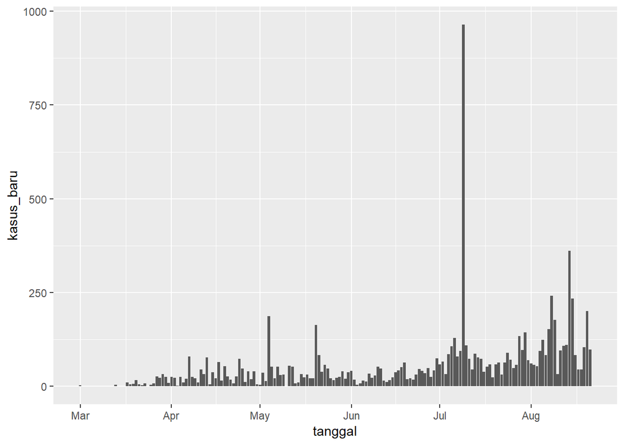

```r
library(ggplot2)
library(hrbrthemes)
ggplot(new_cov_jabar, aes(x = tanggal, y = kasus_baru)) +
  geom_col()
```

### Menunjukkan Melalui Gambar - Pt 2

Anda telah berhasil membuat *bar-chart* yang diminta. Namun grafik tersebut belum memiliki informasi yang jelas serta cenderung membosankan untuk dilihat. Sekarang silakan buat kembali grafik tersebut dengan menggunakan baris kode yang telah dimodifikasi berikut:

[output not shown]

[output not shown]

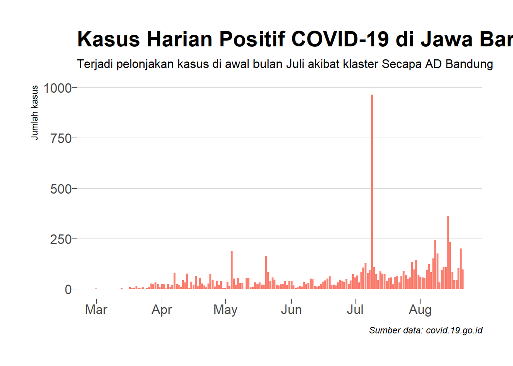

```r
library(ggplot2)
library(hrbrthemes)
ggplot(new_cov_jabar, aes(tanggal, kasus_baru)) +
    geom_col(fill = "salmon") +
    labs(
      x = NULL,
      y = "Jumlah kasus",
      title = "Kasus Harian Positif COVID-19 di Jawa Barat",
      subtitle = "Terjadi pelonjakan kasus di awal bulan Juli akibat klaster Secapa AD Bandung",
      caption = "Sumber data: covid.19.go.id"
      ) +
    theme_ipsum(
      base_size = 13,
      plot_title_size = 21,
      grid = "Y",
      ticks = TRUE
      ) #+
```

```r
#   theme(plot.title.position = "plot")
```

### Grafik untuk Kasus Sembuh

Sekarang buatlah grafik serupa dengan menggunakan data kasus sembuh Pergunakan warna **“olivedrab2”** untuk grafik kasus sembuh!

[output not shown]

[output not shown]

[output not shown]

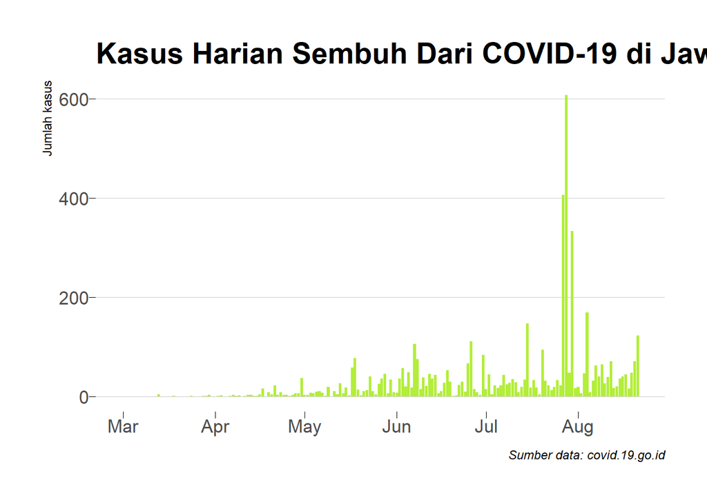

```r
library(ggplot2)
library(hrbrthemes)
ggplot(new_cov_jabar, aes(tanggal, sembuh)) +
  geom_col(fill = "olivedrab2") +
  labs(
    x = NULL,
    y = "Jumlah kasus",
    title = "Kasus Harian Sembuh Dari COVID-19 di Jawa Barat",
    caption = "Sumber data: covid.19.go.id"
  ) +
  theme_ipsum(
    base_size = 13,
    plot_title_size = 21,
    grid = "Y",
    ticks = TRUE
  ) #+
```

```r
 # theme(plot.title.position = "plot")
```

### Grafik untuk Kasus Meninggal

Sekarang buatlah grafik serupa dengan menggunakan data kasus meninggal. Pergunakan warna **“darkslategray4”** untuk kasus meninggal!

[output not shown]

[output not shown]

[output not shown]

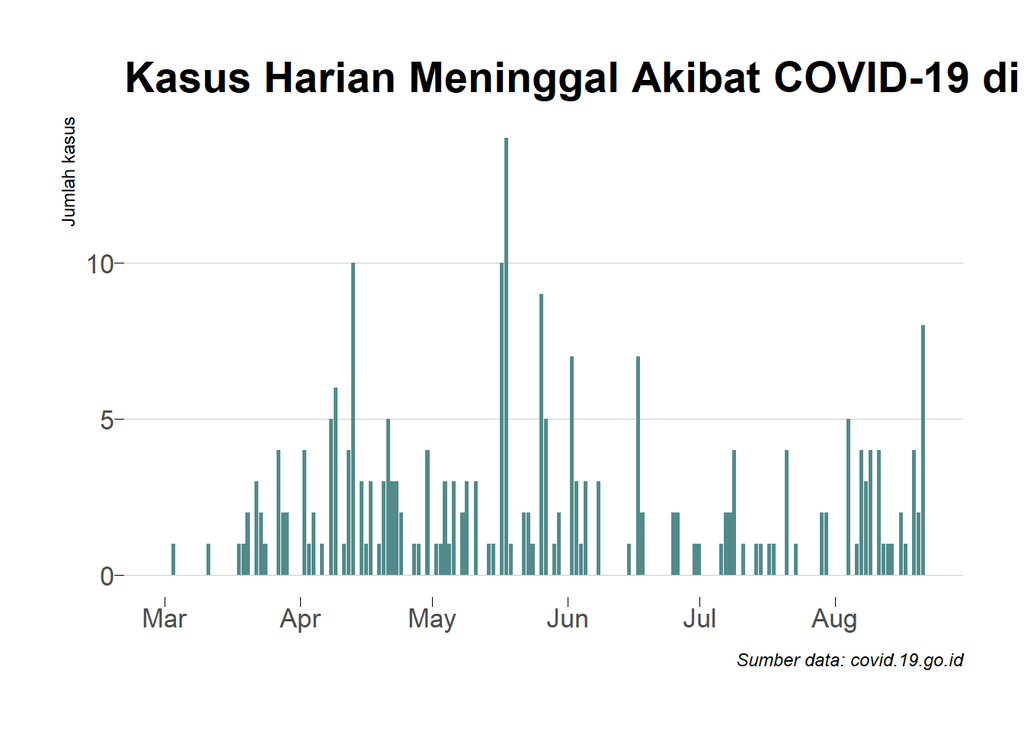

```r
library(ggplot2)
library(hrbrthemes)
ggplot(new_cov_jabar, aes(tanggal, meninggal)) +
  geom_col(fill = "darkslategray4") +
  labs(
    x = NULL,
    y = "Jumlah kasus",
    title = "Kasus Harian Meninggal Akibat COVID-19 di Jawa Barat",
    caption = "Sumber data: covid.19.go.id"
  ) +
  theme_ipsum(
    base_size = 13,
    plot_title_size = 21,
    grid = "Y",
    ticks = TRUE
  ) #+
```

```r
  #theme(plot.title.position = "plot")
```

### Apakah Pekan ini Lebih Baik?

Setelah mengamati grafik perkembangan kasus Anda menyadari bahwa terjadi fluktuasi pertambahan kasus harian. Dilandasi hal tersebut Anda kemudian ingin mencoba mengamati bagaimana perkembangan kasus dalam rentang waktu pekanan. Bagaimanakah caranya?

Anda dapat dengan mudah bekerja dengan data tanggal apabila menggunakan paket `lubridate`. Adapun yang akan digunakan untuk mengekstrak informasi pekan dalam satu tahun adalah fungsi `week()`.

Lengkapilah baris kode berikut untuk menghitung pertambahan kasus pekanan dan simpanlah hasilnya sebagai **cov_jabar_pekanan!** Anda juga diminta untuk menggunakan fungsi `glimpse()` dari `dplyr` untuk melakukan inspeksi data.

```r
library(dplyr)
library(lubridate)
cov_jabar_pekanan <- new_cov_jabar %>%
  count(
    tahun = year(tanggal),
    pekan_ke = week(tanggal),
    wt = kasus_baru,
    name = "jumlah"
  )

glimpse(cov_jabar_pekanan)
```

```
## Observations: 26
## Variables: 3
## $ tahun    <dbl> 2020, 2020, 2020, 2020, 2020, 2020, 2020, 2020, 2020,...
## $ pekan_ke <dbl> 9, 10, 11, 12, 13, 14, 15, 16, 17, 18, 19, 20, 21, 22...
## $ jumlah   <int> 4, 2, 18, 45, 129, 185, 217, 238, 227, 338, 243, 151,...
```

### Menjawab Pertanyaan

Pertanyaan baru muncul di benak Anda setelah melakukan inspeksi terhadap data **cov_jabar_pekanan** tersebut: “Apakah pekan ini lebih baik dari pekan kemarin?”.

Demi menjawab hal tersebut Anda melakukan kalkulasi sederhana dengan tahapan berikut:

- Membuat kolom baru yang berisi jumlah kasus baru dalam satu pekan sebelumnya.
- Kolom ini diberi nama “jumlah_pekanlalu”.
- Mengganti nilai NA pada kolom “jumlah_pekanlalu” dengan nilai 0
- Melakukan komparasi antara kolom “jumlah” dengan kolom “jumlah_pekanlalu”. Hasil * komparasi ini disimpan dalam kolom baru dengan nama “lebih_baik”, isinya adalah TRUE apabila jumlah kasus baru pekan ini lebih rendah dibandingkan jumlah kasus pekan lalu

Lengkapilah baris kode berikut untuk mengerjakan tahapan yang telah Anda rencanakan! Anda akan menggunakan fungsi `lag()` dari `dplyr` untuk membuat kolom “jumlah_pekanlalu”. Perhatikan bahwa disini fungsi tersebut dituliskan sebagai `dplyr::lag()` untuk menghindari konflik dengan fungsi `lag()` dari paket `stats`. Inspeksi hasil pekerjaan Anda dengan menggunakan fungsi `glimpse()`!

```r
library(dplyr)
cov_jabar_pekanan <-
  cov_jabar_pekanan %>%
  mutate(
    jumlah_pekanlalu = dplyr::lag(jumlah, 1),
    jumlah_pekanlalu = ifelse(is.na(jumlah_pekanlalu), 0, jumlah_pekanlalu),
    lebih_baik = jumlah < jumlah_pekanlalu
  )
glimpse(cov_jabar_pekanan)
```

```
## Observations: 26
## Variables: 5
## $ tahun            <dbl> 2020, 2020, 2020, 2020, 2020, 2020, 2020, 202...
## $ pekan_ke         <dbl> 9, 10, 11, 12, 13, 14, 15, 16, 17, 18, 19, 20...
## $ jumlah           <int> 4, 2, 18, 45, 129, 185, 217, 238, 227, 338, 2...
## $ jumlah_pekanlalu <dbl> 0, 4, 2, 18, 45, 129, 185, 217, 238, 227, 338...
## $ lebih_baik       <lgl> FALSE, TRUE, FALSE, FALSE, FALSE, FALSE, FALS...
```

### Membuat Bar Chart

Anda sungguh luar biasa! Dengan menggunakan data hasil perhitungan tersebut maka sekarang Anda dapat membuat bar-chat penambahan kasus pekanan yang ditambahkan informasi baru untuk menjawab pertanyaan: “Apakah pekan ini lebih baik?”

[output not shown]

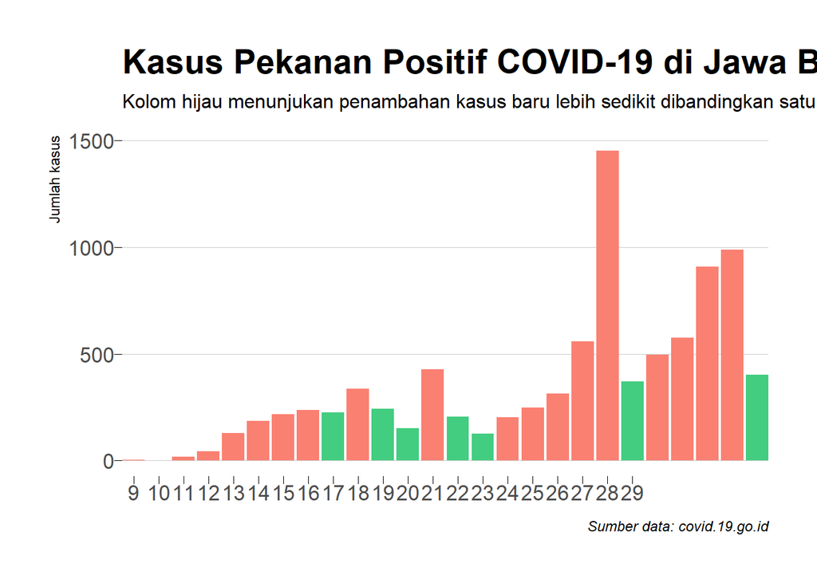

```r
library(ggplot2)
library(hrbrthemes)

ggplot(cov_jabar_pekanan, aes(pekan_ke, jumlah, fill = lebih_baik)) +
geom_col(show.legend = FALSE) +
scale_x_continuous(breaks = 9:29, expand = c(0, 0)) +
scale_fill_manual(values = c("TRUE" = "seagreen3", "FALSE" = "salmon")) +
labs(
  x = NULL,
  y = "Jumlah kasus",
  title = "Kasus Pekanan Positif COVID-19 di Jawa Barat",
  subtitle = "Kolom hijau menunjukan penambahan kasus baru lebih sedikit dibandingkan satu pekan sebelumnya",
  caption = "Sumber data: covid.19.go.id"
  ) +
theme_ipsum(
  base_size = 13,
  plot_title_size = 21,
  grid = "Y",
  ticks = TRUE
  ) #+
```

```r
#theme(plot.title.position = "plot")
```

### Pola dan Dinamika

Ada yang akhirnya sembuh, namun tak sedikit pula yang meninggal akibat COVID-19. Sementara itu penambahan kasus baru terus terjadi di masyarakat. Hal ini mungkin memicu pertanyaan lain di diri Anda: “Hingga saat ini ada berapa kasus yang masih aktif?”. Aktif dalam artian sedang dalam perawatan atau isolasi.

Informasi ini sebenarnya telah disediakan di dalam respon API covid19.go.id yang Anda minta. Namun tidak ada salahnya jika Anda mencoba menghitungnya sendiri, apakah Anda setuju?

Jumlah kasus aktif dapat dihitung dengan cara mengurangi jumlah akumulasi positif dengan jumlah akumulasi sembuh dan jumlah akumulasi meninggal. Anda dapat menggunakan fungsi `cumsum()` untuk menghitung nilai akumulasi dari suatu vektor numerik. Lengkapilah baris kode berikut untuk menghitung jumlah akumulasi kasus aktif, kasus sembuh, dan kasus meninggal!

```r
library(dplyr)
cov_jabar_akumulasi <-
  new_cov_jabar %>%
  transmute(
    tanggal,
    akumulasi_aktif = cumsum(kasus_baru) - cumsum(sembuh) - cumsum(meninggal),
    akumulasi_sembuh = cumsum(sembuh),
    akumulasi_meninggal = cumsum(meninggal)
  )

tail(cov_jabar_akumulasi)
```

```
##        tanggal akumulasi_aktif akumulasi_sembuh akumulasi_meninggal
## 169 2020-08-16            3685             4662                 232
## 170 2020-08-17            3684             4707                 233
## 171 2020-08-18            3713             4723                 233
## 172 2020-08-19            3765             4771                 237
## 173 2020-08-20            3893             4842                 239
## 174 2020-08-21            3860             4965                 247
```

### Membuat Line Chart

Sekarang cobalah Anda buat *line-chart* pola kasus aktif dengan menggunakan fungsi `geom_line()`. Sebagai pengingat, Anda dapat menggunakan templat kode berikut untuk membuat grafik menggunakan `ggplot2()`:

```
ggplot(data = ..., aes(x = ..., y = ...)) +
  geom_xxx()
```

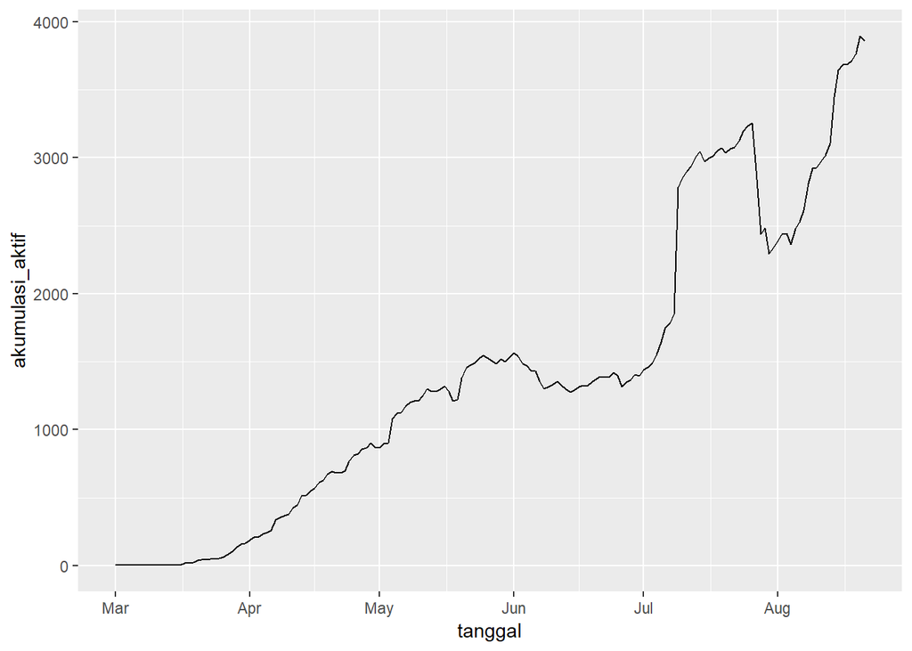

```r
library(ggplot2)
ggplot(data = cov_jabar_akumulasi, aes(x = tanggal, y = akumulasi_aktif)) +
  geom_line()
```

### Kabar Buruk dan Kabar Baik

Sebagai penutup analisis dalam proyek ini Anda diminta untuk membuat grafik komparasi antara akumulasi kasus aktif, kasus sembuh, dan kasus meninggal.

Ada dua pilihan cara yang dapat Anda tempuh untuk membuat grafik tersebut:

1. Menggunakan data **cov_jabar_akumulasi**, kemudian buat tiga *layer* `geom_line()` untuk setiap kolom satu per satu dengan warna garis yang berbeda; atau
2. Melakukan *pivot* pada data **cov_jabar_akumulasi**, kemudian buat satu **layer** `geom_line()` dengan menggunakan **colour aesthetic**

Anda akan diminta untuk menempuh cara nomor 2, yaitu dengan cara melakukan pivot pada data terlebih dahulu. Ketik `TRUE` pada konsol jika Anda setuju!

```r
TRUE
```

```
## [1] TRUE
```

### Transformasi Data

Anda akan menggunakan fungsi `gather()` dari paket `tidyr` untuk mentransformasi data **cov_jabar_akumulasi**. Data tersebut akan dirubah dari yang semula berformat *wide* menjadi format *long*. AKtifkanlah paket `tidyr` terlebih dahulu dan lengkapilah baris kode berikut untuk melakukan pivot data. Simpan hasil transformasi data tersebut sebagai **cov_jabar_akumulasi_pivot**! Perhatikan hasil dari fungsi `dim()` sebelum dan setelah Anda melakukan transformasi data.

```r
library(dplyr)
library(tidyr)
dim(cov_jabar_akumulasi)
```

```
## [1] 174   4
```

```r
cov_jabar_akumulasi_pivot <-
  cov_jabar_akumulasi %>%
  gather(
    key = "kategori",
    value = "jumlah",
    -tanggal
  ) %>%
  mutate(
    kategori = sub(pattern = "akumulasi_", replacement = "", kategori)
  )

dim(cov_jabar_akumulasi_pivot)
```

```
## [1] 522   3
```

```r
glimpse(cov_jabar_akumulasi_pivot)
```

```
## Observations: 522
## Variables: 3
## $ tanggal  <date> 2020-03-01, 2020-03-02, 2020-03-03, 2020-03-04, 2020...
## $ kategori <chr> "aktif", "aktif", "aktif", "aktif", "aktif", "aktif",...
## $ jumlah   <int> 3, 3, 3, 4, 4, 5, 5, 5, 5, 5, 5, 6, 6, 6, 6, 7, 18, 2...
```

### pivot_longer()

Semenjak tidyr versi 1.0.0, Anda disarankan untuk menggunakan fungsi `pivot_longer()` sebagai pengganti `gather()` dan `pivot_wider()` sebagai pengganti `spread()`. `pivot_longer()` dan `pivot_wider()` memiliki fitur yang lebih lengkap dibandingkan gather() dan spread(). Proses transformasi **cov_jabar_akumulasi** menjadi **cov_jabar_akumulasi_pivot** dapat dikerjakan dengan menggunakan `pivot_longer()` sebagai berikut:

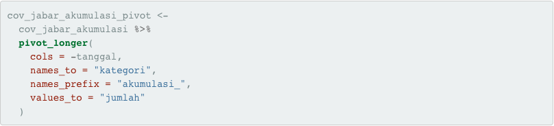

figure.1

Anda dapat mencoba mempraktekkan potongan coding tersebut pada R Studio pada desktop masing-masing dan apakah Anda menemukan perbedaan signifikan antara baris kode di atas dan baris kode sebelumnya yang Anda gunakan?

### Tahap Terakhir

Anda hampir selesai! Pada tahap terakhir ini Anda cukup salin dan jalankan baris kode berikut di konsol untuk membuat grafik komparasi antara akumulasi kasus aktif, kasus sembuh dan kasus meninggal:

[output not shown]

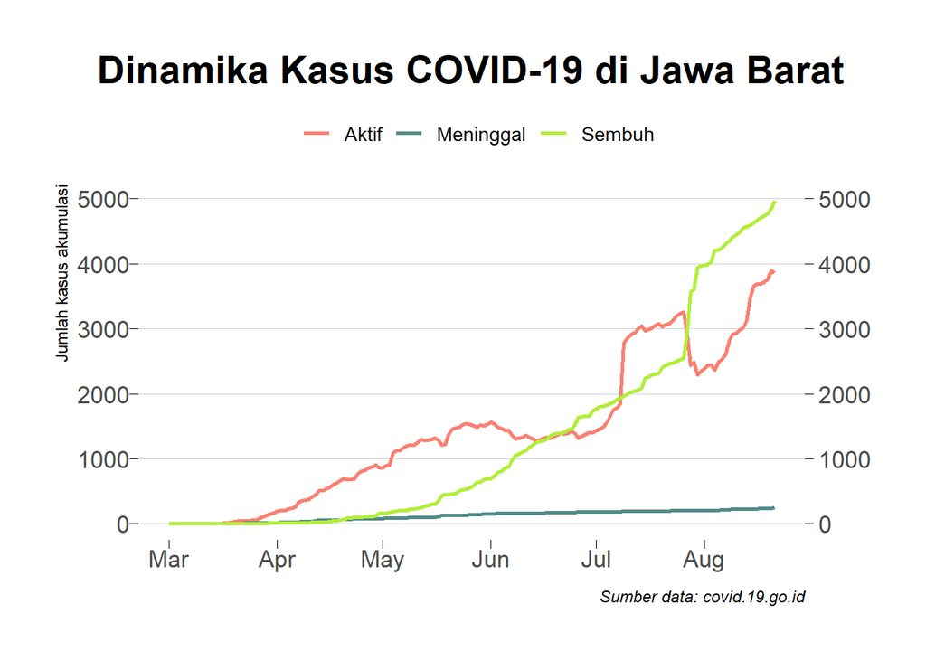

```r
library(ggplot2)
library(hrbrthemes)
ggplot(cov_jabar_akumulasi_pivot, aes(tanggal, jumlah, colour = (kategori))) +
  geom_line(size = 0.9) +
  scale_y_continuous(sec.axis = dup_axis(name = NULL)) +
  scale_colour_manual(
    values = c(
      "aktif" = "salmon",
      "meninggal" = "darkslategray4",
      "sembuh" = "olivedrab2"
    ),
    labels = c("Aktif", "Meninggal", "Sembuh")
    ) +
  labs(
    x = NULL,
    y = "Jumlah kasus akumulasi",
    colour = NULL,
    title = "Dinamika Kasus COVID-19 di Jawa Barat",
    caption = "Sumber data: covid.19.go.id"
  ) +
  theme_ipsum(
    base_size = 13,
    plot_title_size = 21,
    grid = "Y",
    ticks = TRUE
  ) +
  theme(
    plot.title = element_text(hjust = 0.5),
    legend.position = "top"
  )
```

### Kesimpulan dan Komentar

Selamat Anda telah menyelesaikan proyek analisis COVID-19 ini! Anda telah berhasil melakukan impor data melalui API, melakukan transformasi data, serta membuat visualisasi untuk mengkomunikasikan hasil analisis data tentang COVID-19.

Anda dipersilakan untuk selanjutnya mengembangkan analisis dengan cara mengambil studi kasus provinsi lain atau bahkan melakukan komparasi antar provinsi. Anda dapat menggunakan skrip dasar yang tersedia pada tautan ini untuk memulai analisis. Dengan menggunakan studi kasus provinsi pilihan Anda, dapatkah Anda menjawab dua tantangan ini:

- Apakah jumlah kasus di pekan ini lebih rendah dibandingkan pekan kemarin dan dua pekan kemarin secara berturut-turut? Buatlah visualisasinya!
- Salah satu metrik yang dapat dihitung untuk mengamati persebaran COVID-19 di masyarakat adalah ‘Seventh-Day Amplification Factor’ (silakan baca ini dan ini). Dapatkah Anda menghitung metrik tersebut?

Silakan bagikan hasil temuan Anda di LinkedIn atau media sosial dengan tag akun DQLab dan saya ya! Semoga Anda tetap sehat, waspada dan tetap tenang dalam menghadapi pandemi COVID-19. Selamat dan sukses selalu!

### certificate

[figure not shown]

cerificate